# bkcd - bkcd.R - xkcd like plots using base graphicsfunctions and operators

Detlef Groth, University of Potsdam

2022-01-26

## NAME

*bkcd.R* - R environment and standalone application to create xkcd like plots using the R graphics library.

## TABLE OF CONTENTS

- SYNOPSIS
- DESCRIPTION
- USAGE
- FUNCTIONS
  - bkcd$axes - creates xkcd compatible axes
  - bkcd$emptyplot - creates an empty plot surface
  - bkcd$points - add polygon or line based plotting characters to an existing plot
  - bkcd$tikz2xkcd - convert TikZ files to xkcd compatible TikZ files with decorations
  - pkcd$xyplot - xkcd compatible plotting of two numerical vectors
- EXAMPLES
- CITATION
- DOCUMENTATION
- LINKS
- TODOS
- CHANGELOG
- LICENSE / AUTHOR

## SYNOPSIS

Sourcing:

```
source("~/R/dlib/bkcd.R")
library(tikzDevice)
tikz("file.tex",sanitize=TRUE)
barplot(1:4,names.arg=LETTERS[1:4],col=2:5,axes=FALSE,
        main="barplot",ylim=c(0,4.5))
bkcd$axes(2)
dev.off()
bkcd$tikz2xkcd("file.tex","file.pdf",fontname="Humor Sans")
```

Standalone application:

```
Rscript ~/R/dlib/bkcd.R --help
Rscript ~/R/dlib/bkcd.R --convert file.tex file.png
Rscript ~/R/dlib/bkcd.R --test # should create the barplot above
```

## DESCRIPTION

The file *bkcd.R* contains the code for an R environment *bkcd* to create xkcd like plots using the base graphics package of R. The file *bkcd.R* can be sourced into your own R code or it can be used as a standalone application to convert existing TikZ figures created with base graphics methods into other TikZ-TeX filesand futher converted directly into PDF files (Using the xelatex compiler) and thereafter as well into PNG files (using the ghostscript interpreter).  
The R script is based on the TikZ graphicsdevice and an installed comic font like [Humor Sans](https://github.com/shreyankg/xkcd-desktop), [Fuzzy Bubbles](https://fonts.google.com/specimen/Fuzzy+Bubbles) or the [xkcd Script font]((https://github.com/ipython/xkcd-font/tree/master/xkcd-script/font).

**Attention:** Please note, that the image generation via the pipeline R-latex-ghostscript is much slower than native image generation within R.  
For instance this complete document took almost 3 minutes to compile on my Linux Machine (4 CPU’s 2.1Ghz, 16GB RAM). In case of using it within a R-Markdown document, like this one, use the code chunk option `cache=TRUE` if appropriate, this way the compile time for this document was reduced to 0.51 seconds!! if the code in the code chunks did not change and just modifications in the documentation text were done.  
Furthermore do not expect that all bells and whistles of R plots will work as expected. Use this code carefully, for instance as an opener slide in a presentation or to demonstrate ideas or to do less serious things, the plots might generated by this script are less useful to analyze real data.

Requirements:

- R with package *tikzDevice*
- LaTeX with *xelatex* and packages *standalone*, *tikz*, *pgf*, PDF output
- Optional: Ghostscript for PNG conversion, you could choose any other converter by yourself from the PDF file produced by *xelatex*
- Optional: pdf2svg for SVG generation (optional), again you could choose any other converter by yourself from the PDF file produced by *xelatex*

Public Functions:

- bkcd$axes - creates xkcd compatible axes
- bkcd$emptyplot - creates an empty plot surface
- bkcd$points - add polygon or line based plotting characters to an existing plot
- bkcd$tikz2xkcd - convert TikZ files to xkcd compatible TikZ files with decorations
- pkcd$xyplot - xkcd compatible plotting of two numerical vectors

## USAGE

### Source bkcd.R

To use the functions in your own R programs and analysis just source the file `bkcd.R` into your R application. It is recommended to place the file into the R folder in your HOME directory.

```r
source("bkcd.R")
```

All function of this file are added to an environment variable called *bkcd*.  
To have a look which variables and functions exists in this namesspace you can use the function call `ls(bkcd)`. Here is the output:

```r
ls(bkcd)
```

```
## [1] "axes"      "emptyplot" "FILENAME"  "points"    "tikz2xkcd" "Usage"
## [7] "VERSION"   "xyplot"
```

Public methods names start with a lowercase letter. You should only use them in your R scripts.

```r
ls(bkcd,pattern="^[a-z]")
```

```
## [1] "axes"      "emptyplot" "points"    "tikz2xkcd" "xyplot"
```

### Application bkcd.R

Alternatively, if you make the script executable and you  
move into a folder belonging to your PATH variable, you can use the script `bkcd.R` as a standalone executable to convert TikZ figure files into xkcd-tex files and optional process them further to PNG and PDF files like this:

```
$ bkcd.R --convert infile.tex infile.png
```

Possible output file formats are :

- `.tex` - standalone texfile with embedded LaTeX commands for xkcd style (not all TikZ figure files from non-R-tikzDevice generated ones will work!)
- `.pdf` - tex document with xkcd style macros is further processed to a pdf file using `xelatex`
- `.png` - tex document with xkcd style macros is processed to pdf (xelatex), then to png using ghostscript

For a pipeline overview see the flowchart below. For svg output I recommend using the command line tool pdf2svg on the pdf output file.

## FUNCTIONS

**bkcd$axes(which=c(1,2))**

> Creates xkcd compatible axes.

> This function creates axes which are compatible for the xkcd display.  
> In standard axes plotting we have acutally two lines which are exactly on the same line, the box-line and the axis line. During the sketching then the two lines diverge slightly which might be a little bit disturbuing. Below in the example section you can compare the two versions.

> Arguments:
> - *which* - vector with numbers from 1 to 4 for the axis, default: c(1,2)

> Examples:

> Below two examples, left the traditional approach to create boxed histograms and xy-plots. Right the fix using the `bkcd$axes` function. In the left plots, there is a visible double line on the x- and on the y-axis.

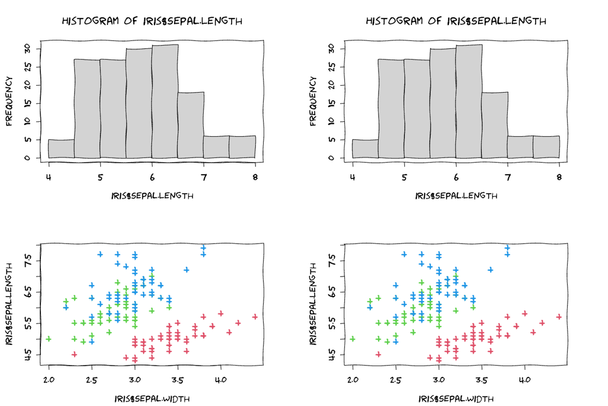

> ```r
> library(tikzDevice)
> # sanitize=TRUE to avoid interpretation of special symbols
> # like the Dollar symbol as LaTeX symbols
> tikz("tikz-axes.tex",sanitize=TRUE,width=9,height=6)
> data(iris)
> par(mfcol=c(2,2),mai=rep(0.6,4))
> # standard approach
> hist(iris$Sepal.Length)
> box()
> plot(iris$Sepal.Length~iris$Sepal.Width,
>    col=as.numeric(iris$Species)+1,pch="+",cex=2)
> # using bkcd$axes avoids line overlays
> hist(iris$Sepal.Length,axes=FALSE)
> bkcd$axes()
> plot(iris$Sepal.Length~iris$Sepal.Width,axes=FALSE,
>    col=as.numeric(iris$Species)+1,pch="+",cex=2)
> bkcd$axes()
> dev.off()
> bkcd$tikz2xkcd("tikz-axes.tex","tikz-axes.png",fontname="Humor Sans")
> ```

**Figure: 1**: Effect of double lines on x and y-axis.

**bkcd$emptyplot(…)**

> Creates an empty plot surface.

> This function creates an empty plot surface which can be used as a starter to build your own plot or figures later in a stepwise manner.

> Examples:

> Let’s rebuild the famous [“The Data So Far”](https://xkcd.com/373/) comic:

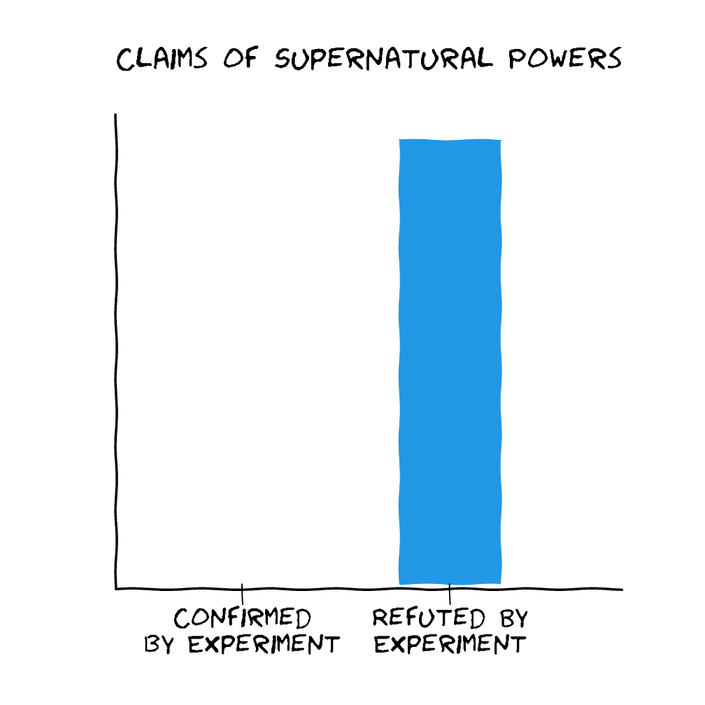

> ```r
> library(tikzDevice)
> tikz("tikz-power.tex")
> bkcd$emptyplot()
> lines(x=c(0,1),y=c(0.02,0.02),lwd=4) # xaxis
> lines(x=c(0,0),y=c(0.02,0.95),lwd=4) # yaxis
> rect(0.56,0.03,0.76,0.9,col=4,border=4) # box
> lines(x=c(0.66,0.66),y=c(-0.01,0.03),lwd=2) # tick1
> lines(x=c(0.25,0.25),y=c(-0.01,0.03),lwd=2) # tick2
> axis(1,lwd=0,c("Confirmed\n by Experiment",
>   "Refuted By\nExperiment"),at=c(0.25,0.66),
>   cex.axis=1.6) # labels
> mtext(side=3,"    Claims of Supernatural Powers",cex=1.8)
> dev.off()
> bkcd$tikz2xkcd("tikz-power.tex","tikz-power.png",fontname="Humor Sans")
> ```

**Figure 2**: Claims of Supernatural Powers (emptyplot-demo).

**bkcd$points(x,y,…)**

> Add polygon based plotting characters to an existing plot.

> This function adds polygon based plotting characters to an existing plot. Using a polygon ensures that the plotting characters are made more sketchy using the tikz/pgf LaTeX document with the xkcd style.

> Arguments:
> - *x* - vector of x coordinates
> - *y* - vector of y coordinates
> - *pch* - type of polygon, can be either ‘circ’, ‘rect’, ‘dia’, ‘tri’ or ‘star’, default: ‘circ’
> - *col* - color, default: 2 (red)
> - *fill* - should the polygon be filled, default: TRUE
> - *cex* - character expansion, default: 1

> See also:
> - bkcd$xyplot

> Examples:

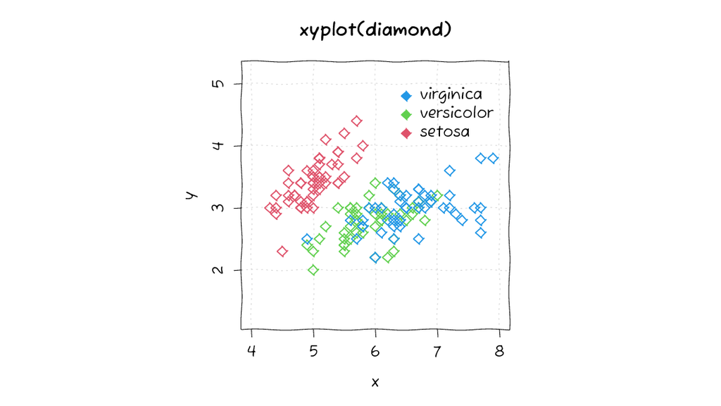

> ```r
>  library(tikzDevice)
>  tikz('tikz-plotpoints.tex', width = 8, height = 4.5)
>  data(iris)
>  bkcd$xyplot(iris$Sepal.Length,iris$Sepal.Width,
>     col=as.numeric(iris$Species)+1,
>     pch="dia",xlim=c(4,8),main="xyplot(diamond)",
>     fill=FALSE)
>  bkcd$points(x=rep(6.5,3),y=c(4.2,4.5,4.8),pch="dia",
>     col=2:4,cex=1)
>  text(x=rep(6.6,3),y=c(4.2,4.5,4.8),
>     labels=c('setosa','versicolor','virginica'),pos=4)
>  dev.off()
>  bkcd$tikz2xkcd("tikz-plotpoints.tex","tikz-plotpoints.png",fontname="Fuzzy Bubbles")
> ```

**Figure 3**: Iris data plot (points-demo).

**bkcd$xyplot(x,y,…)**

> Xkcd styled plotting of two numerical vectors.

> This function ensures the right placement of the axes for the xyplot uses polygon based plotting characters to ensure the sketch effect.

> Arguments:
> - *x* - vector of x coordinates
> - *y* - vector of y coordinates
> - *pch* - type of polygon, can be either ‘circ’, ‘rect’, ‘dia’, ‘tri’ or ‘star’, default: ‘circ’
> - *col* - color, default: 2 (red)
> - *fill* - should the polygon be filled, default: TRUE
> - *cex* - character expansion, default: 1
> - *axes* - should the axes be plotted, default: TRUE
> - *grid* - should the internal grid be plotted, default: TRUE
> - *asp* - aspect ratio, default: 1
> - *pty* - pty paramater to keep ratio of plot width and height ‘s’ - is same/square, ‘m’ is maximal area, default: ‘s’
> - *…* - remaining arguments are forwarded to the standard plot function

> See also:
> - bkcd$points

> Examples:

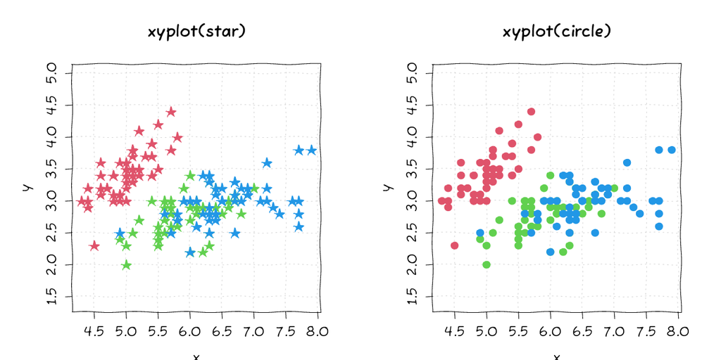

> ```r
>  library(tikzDevice)
>  tikz('tikz-xyplot.tex', width = 9, height = 4.5)
>  par(mfrow=c(1,2),mai=c(0.6,0.6,0.8,0.2))
>  data(iris)
>  bkcd$xyplot(iris$Sepal.Length,iris$Sepal.Width,
>     col=as.numeric(iris$Species)+1,
>     pch="star",main="xyplot(star)")
>  bkcd$xyplot(iris$Sepal.Length,iris$Sepal.Width,
>     col=as.numeric(iris$Species)+1,
>     pch="circ",main="xyplot(circle)")
>  dev.off()
>  bkcd$tikz2xkcd("tikz-xyplot.tex","tikz-xyplot.png",fontname="Fuzzy Bubbles")
> ```

**Figure 4**: xy-plot for iris data (xyplot-demo).

**bkcd$tikz2xkcd(x,y,…)**

> Convert TikZ files to xkcd compatible tikz files with decorations.

> This function is the actual main converting function.  
> It converts a standard TeX-TikZ file (created with the *tikzDevide* package), to a TikZ file with xkcd sytling LaTeX macros and thereafter compiles the latter to a PDF file using the *xelatex* executable.  
> In case that the file extension of the requested output file is PNG, the PDF file is further converted to a PNG using the Ghostscript interpreter.

> Arguments:
> - *infile* - TikZ LaTeX input file created with the the *tikz* command from the *tikzDevice* package
> - *outfile* - a LaTeX or PNG or a PDF output file
> - *standalone* - should the generated file be a standalone LaTeX files which can be compiled directly using the xelatex application, in case of PNG and PDF output this is automatically standalone=TRUE, default: FALSE
> - *fontname* - the font which should be used, should be an installed OTF or TTF file in comic style
> - *include* - which additional tex files should be included, default: NULL
> - *fontsize* - which LaTeX fontsize, default: “large”
> - *resolution* - resolution in DPI for PNG output, default: 144

> Examples:

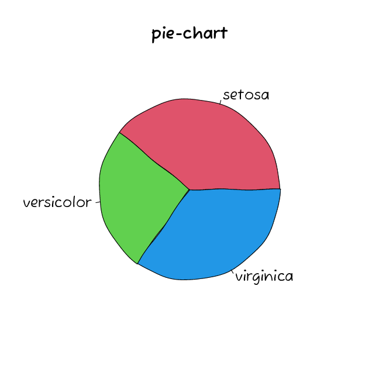

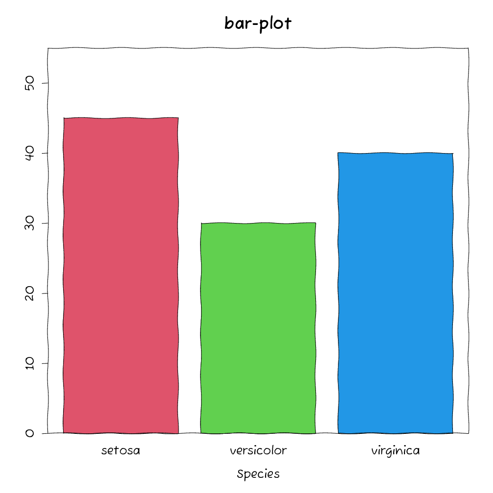

> ```r
> tikz('tikz-pie.tex', width = 4.5, height = 4.5)
> par(mai=rep(0.8,4))
> pie(table(iris$Species)*c(0.9,0.6,0.8),
>   col=2:4,main="pie-chart")
> dev.off()
> bkcd$tikz2xkcd("tikz-pie.tex","tikz-pie.png",fontname="Fuzzy Bubbles")
> tikz('tikz-barplot.tex')
> barplot(table(iris$Species)*c(0.9,0.6,0.8),ylim=c(0,55),
>         col=2:4,main="bar-plot",xlab="Species",axes=FALSE,cex.main=1.4)
> axis(2,lwd=0,lwd.ticks=1)
> box()
> dev.off()
> bkcd$tikz2xkcd("tikz-barplot.tex","tikz-barplot.png",fontname="Fuzzy Bubbles")
> ```

**Figure 5**: pie and barplot demos (tikz2xkcd-demo).

## EXAMPLES

Below a few more examples. Let’s start with a boxplot:

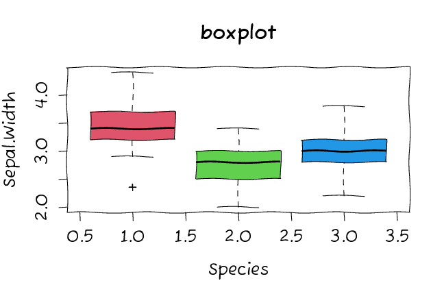

```r
tikz('tikz-boxplot.tex', width = 4.5, height = 3.0)
boxplot(iris$Sepal.Width ~ iris$Species,col=2:4,
        main="boxplot",pch="+",xlab="Species",
        ylab="Sepal.Width",axes=FALSE)
bkcd$axes()
#axis(1,lwd=0,lwd.ticks=1,labels=levels(iris$Species),at=1:3)
dev.off()
bkcd$tikz2xkcd("tikz-boxplot.tex","tikz-boxplot.png",fontname="Fuzzy Bubbles")
```

**Figure 6**: boxplot demo.

Now a flowchart which illustrates as well the concept of chessboard coordinate based layouts:

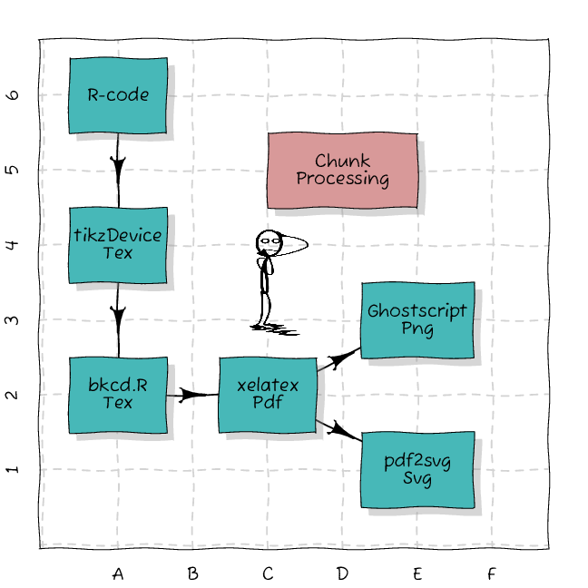

```r
library(diagram)
library(png)
# https://svgsilh.com/search/stickman-1.html
pp <- readPNG("stickman.png")
tikz('tikz-flowchart.tex', width = 4.5, height = 4.5)
par(cex=0.8,mai=rep(0.3,4))
# setup elements using chessboard coordinates
board = function (x,y=NULL,func=NULL,...) {
    f2v = function (x) {
        col=substr(x,1,1)
        col=as.integer(which(LETTERS==col))
        row=as.integer(substr(x,2,2))
        return(c(col,row))
    }
    from = f2v(x)
    if (class(y)=="function") {
        invisible(y(from,...))

    } else {
        to   = f2v(y)
        invisible(func(from,to,...))
    }
}
# helper function to set defaults
trect = function (pos,box.col="#47B8B8",
                  radx=0.65,rady=0.5,
                  shadow.size = 0.1,shadow.col = "#99999966",...) {
   textrect(pos,box.col=box.col,radx=radx,rady=rady,
            shadow.size=shadow.size,
            shadow.col=shadow.col,...)
}

# the surface
bkcd$emptyplot(xlim=c(0.2,6.5),ylim=c(0.2,6.5))
# display the coordinate system - just for illustration
grid(lwd=2,lty=2)
axis(1,at=c(1:6),labels=LETTERS[1:6],lwd=0)
axis(2,at=c(1:6),labels=1:6,lwd=0)
box()

# first the lines
board('A6','A4',straightarrow)
board('A4','A2',straightarrow)
board('A2','C2',straightarrow)
board('C2','E3',straightarrow)
board('C2','E1',straightarrow)

# then the rectangles
board('A6',trect,lab="R-code")
board('A4',trect,lab="tikzDevice\nTex")
board('A2',trect,lab="bkcd.R\nTex")
board('C2',trect,lab="xelatex\nPdf")
board('E3',trect,radx=0.75,lab="Ghostscript\nPng")
board('E1',trect,radx=0.75,lab="pdf2svg\nSvg")
board('D5',trect,radx=1.0,lab="Chunk\nProcessing",box.col="#D89999")
# finished ??
rasterImage(pp,2.5,2.8,3.8,4.2)
dev.off()
# conversion
bkcd$tikz2xkcd("tikz-flowchart.tex","tikz-flowchart.png",fontname="Fuzzy Bubbles")
# just a pdf
bkcd$tikz2xkcd("tikz-flowchart.tex","tikz-flowchart.pdf",fontname="Fuzzy Bubbles")
```

**Figure 7**: flowchart demo.

Please note, the `emptyplot` function keeps the aspect ratio, this is here required as it avoids resizing the board differentially in the X and Y dimension.

## CITATION

How to cite this script:

```
# notrun
@Misc{Groth2022bkcd,
  author =   {Detlef Groth},
  title =    {bkcd.{R} - {R} functions to create XKCD like plots and figures using base graphics.},
  howpublished = {\url{https://github.com/mittelmark/Rcode},
  year = {2022}
}
```

Groth, D. (2022). bkcd.R - R functions to create XKCD like plots and figures using base graphics. https://github.com/mittelmark/Rcode

## DOCUMENTATION

This documentation was created directly from the file *bkcd.R* using the following commands in the terminal:

```
# notrun
Rscript bkcd.R --docu
```

The script `bkcd.R` can be executed directly from the command line as described above, using the docu flag all lines starting with  
the `#'` character sequence are extracted and then processed using the library rmarkdown which evaluates the embedded code chunks.

## LINKS

- useful fonts:
  - [xkcd Script](https://github.com/ipython/xkcd-font/tree/master/xkcd-script/font)
  - [Humor Sans](https://github.com/shreyankg/xkcd-desktop)
  - [Fuzzy Bubbles](https://fonts.google.com/specimen/Fuzzy+Bubbles)

Here a comparison of the three fonts:

```r
bkcd$tikz2xkcd("tikz-boxplot.tex","tikz-boxplot-humor.png",fontname="Humor Sans")
bkcd$tikz2xkcd("tikz-boxplot.tex","tikz-boxplot-xkcd.png",fontname="xkcd Script")
```

Fuzzy Bubbles

Humor Sans

xkcd Script

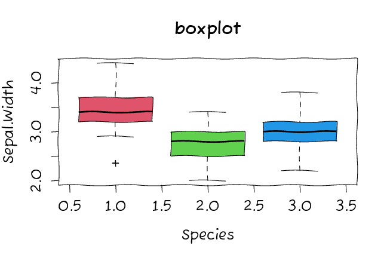

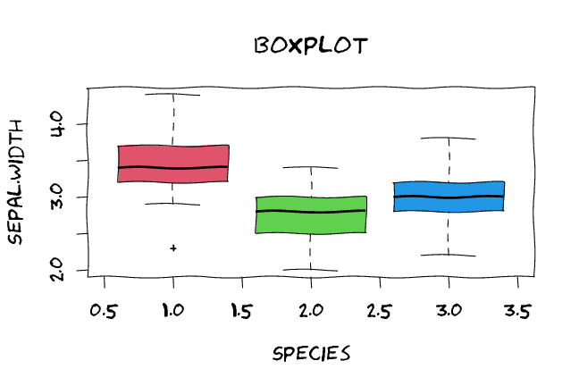

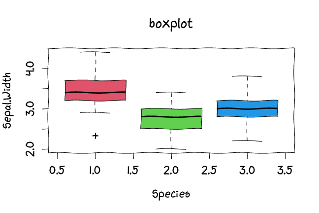

**Table 1**: Fonts demo.

## TODO’s

- embedding svg conversion using pdf2svg
- deleting temporary LaTeX files, they are currently left for inspection
- checking svg2tikz for using Cairo-Svg instead of [tikzDevice](https://cran.r-project.org/web/packages/tikzDevice/) for output
- caching of subsequent runs of tikz2xkcd, first pdf, then png to avoid code re-execution if not neccessary

## DISCLAIMER

There is no warranty of any kind! Use at your own risk!!

These R functions should be used using the basic graphics engine. Users of ggplot2 should use the xkcd package from CRAN, see here: https://cran.r-project.org/package=xkcd, the lattice library seems not to work with the tikzDevice package.

## LICENSE (MIT)

Copyright 2022 Detlef Groth, Scwielowsee, Germany

Permission is hereby granted, free of charge, to any person obtaining a copy of this software and associated documentation files (the “Software”), to deal in the Software without restriction, including without limitation the rights to use, copy, modify, merge, publish, distribute, sublicense, and/or sell copies of the Software, and to permit persons to whom the Software is furnished to do so, subject to the following conditions:

The above copyright notice and this permission notice shall be included in all copies or substantial portions of the Software.

THE SOFTWARE IS PROVIDED “AS IS”, WITHOUT WARRANTY OF ANY KIND, EXPRESS OR IMPLIED, INCLUDING BUT NOT LIMITED TO THE WARRANTIES OF MERCHANTABILITY, FITNESS FOR A PARTICULAR PURPOSE AND NONINFRINGEMENT. IN NO EVENT SHALL THE AUTHORS OR COPYRIGHT HOLDERS BE LIABLE FOR ANY CLAIM, DAMAGES OR OTHER LIABILITY, WHETHER IN AN ACTION OF CONTRACT, TORT OR OTHERWISE, ARISING FROM, OUT OF OR IN CONNECTION WITH THE SOFTWARE OR THE USE OR OTHER DEALINGS IN THE SOFTWARE.